# **Used Cars Price Prediction Report**

## **1. Problem Definition**

### **The Context**

Used car price prediction is critical because it empowers buyers, sellers, and financial institutions to make informed decisions. Accurate pricing leads to fair transactions, reduced information asymmetry, and a more efficient used car market. For example, dealerships can optimize inventory, while banks can better assess loan risks.

### **The Objective**

The main goal is to build a robust regression model that accurately predicts the used car price (in INR 100,000). This model will help stakeholders determine fair market prices, streamline negotiations, and improve market transparency.

### **The Key Questions**

- What factors influence used car prices? (e.g., Year, Kilometers driven, Fuel_Type, Transmission, etc.)
- How do numerical and categorical features relate to price? (Are variables like Year and Mileage significant predictors?)
- Is data transformation (e.g., log transformation) necessary? (Does the distribution of the price variable require normalization?)
- Can feature engineering improve predictions? (For instance, can we extract the brand name from the ‘Name’ column to reduce high cardinality?)

### **The Problem Formulation**

Using data science, we aim to solve a regression problem where the target variable is the used car price. Our approach involves data cleaning, exploratory data analysis (EDA), feature engineering, model building, hyperparameter tuning, and performance evaluation.

## **2. Data Dictionary**

| Field | Description |
| --- | --- |
| S.No. | Serial Number |
| Name | Name of the car (includes Brand and Model name) |
| Location | City where the car is being sold or available for purchase |
| Year | Manufacturing year of the car |
| Kilometers_driven | Total kilometers driven by previous owner(s) (in KM) |
| Fuel_Type | Type of fuel used (Petrol, Diesel, Electric, CNG, LPG) |
| Transmission | Transmission type (Automatic / Manual) |
| Owner | Type of ownership |
| Mileage | Standard mileage offered by the car company (in kmpl or km/kg) |
| Engine | Engine displacement (in CC) |
| Power | Maximum power of the engine (in bhp) |
| Seats | Number of seats in the car |
| New_Price | Price of a new car of the same model (in INR 100,000) |
| Price | Price of the used car (in INR 100,000) – Target Variable |

## **3. Loading Libraries and Data**

```python
# Importing required libraries
import pandas as pd
import numpy as np
import matplotlib.pyplot as plt
import seaborn as sns

# Machine Learning libraries
from sklearn.model_selection import train_test_split, GridSearchCV
from sklearn.linear_model import LinearRegression
from sklearn.tree import DecisionTreeRegressor
from sklearn.ensemble import RandomForestRegressor
from sklearn.metrics import mean_squared_error

# For display in notebooks
%matplotlib inline
```

```python
# Load the dataset from the provided path
dataset_path = "/content/used_cars (1).csv"
df = pd.read_csv(dataset_path)
print("Dataset Shape:", df.shape)
df.head()
```

```
Dataset Shape: (7253, 14)
```

|  | S.No. | Name | Location | Year | Kilometers_Driven | Fuel_Type | Transmission | Owner_Type | Mileage | Engine | Power | Seats | New_price | Price |
| --- | --- | --- | --- | --- | --- | --- | --- | --- | --- | --- | --- | --- | --- | --- |
| 0 | 0 | Maruti Wagon R LXI CNG | Mumbai | 2010 | 72000 | CNG | Manual | First | 26.60 | 998.0 | 58.16 | 5.0 | NaN | 1.75 |
| 1 | 1 | Hyundai Creta 1.6 CRDi SX Option | Pune | 2015 | 41000 | Diesel | Manual | First | 19.67 | 1582.0 | 126.20 | 5.0 | NaN | 12.50 |
| 2 | 2 | Honda Jazz V | Chennai | 2011 | 46000 | Petrol | Manual | First | 18.20 | 1199.0 | 88.70 | 5.0 | 8.61 | 4.50 |
| 3 | 3 | Maruti Ertiga VDI | Chennai | 2012 | 87000 | Diesel | Manual | First | 20.77 | 1248.0 | 88.76 | 7.0 | NaN | 6.00 |
| 4 | 4 | Audi A4 New 2.0 TDI Multitronic | Coimbatore | 2013 | 40670 | Diesel | Automatic | Second | 15.20 | 1968.0 | 140.80 | 5.0 | NaN | 17.74 |

## **4. Data Overview, Observations, and Sanity Checks**

### **Data Overview**

```python
# Basic information about the dataset
print(df.info())

# Summary statistics for numerical features
print(df.describe())

# Check for missing values
print("Missing Values:\n", df.isnull().sum())
```

```
<class 'pandas.core.frame.DataFrame'>
RangeIndex: 7253 entries, 0 to 7252
Data columns (total 14 columns):
 #   Column             Non-Null Count  Dtype
---  ------             --------------  -----
 0   S.No.              7253 non-null   int64
 1   Name               7253 non-null   object
 2   Location           7253 non-null   object
 3   Year               7253 non-null   int64
 4   Kilometers_Driven  7253 non-null   int64
 5   Fuel_Type          7253 non-null   object
 6   Transmission       7253 non-null   object
 7   Owner_Type         7253 non-null   object
 8   Mileage            7251 non-null   float64
 9   Engine             7207 non-null   float64
 10  Power              7078 non-null   float64
 11  Seats              7200 non-null   float64
 12  New_price          1006 non-null   float64
 13  Price              6019 non-null   float64
dtypes: float64(6), int64(3), object(5)
memory usage: 793.4+ KB
None
             S.No.         Year  Kilometers_Driven      Mileage       Engine  \
count  7253.000000  7253.000000       7.253000e+03  7251.000000  7207.000000
mean   3626.000000  2013.365366       5.869906e+04    18.141580  1616.573470
std    2093.905084     3.254421       8.442772e+04     4.562197   595.285137
min       0.000000  1996.000000       1.710000e+02     0.000000    72.000000
25%    1813.000000  2011.000000       3.400000e+04    15.170000  1198.000000
50%    3626.000000  2014.000000       5.341600e+04    18.160000  1493.000000
75%    5439.000000  2016.000000       7.300000e+04    21.100000  1968.000000
max    7252.000000  2019.000000       6.500000e+06    33.540000  5998.000000

             Power        Seats    New_price        Price
count  7078.000000  7200.000000  1006.000000  6019.000000
mean    112.765214     5.280417    22.779692     9.479468
std      53.493553     0.809277    27.759344    11.187917
min      34.200000     2.000000     3.910000     0.440000
25%      75.000000     5.000000     7.885000     3.500000
50%      94.000000     5.000000    11.570000     5.640000
75%     138.100000     5.000000    26.042500     9.950000
max     616.000000    10.000000   375.000000   160.000000
Missing Values:
 S.No.                   0
Name                    0
Location                0
Year                    0
Kilometers_Driven       0
Fuel_Type               0
Transmission            0
Owner_Type              0
Mileage                 2
Engine                 46
Power                 175
Seats                  53
New_price            6247
Price                1234
dtype: int64
```

### **Observations & Sanity Checks:**

- Verify data types and ensure that numerical columns (e.g., Year, - Kilometers_driven) are correctly recognized.
- Identify any missing values and decide on a treatment method.
- Check for unrealistic values or outliers in key columns.

## **5. Exploratory Data Analysis (EDA)**

### **5.1 Summary Statistics and Unique Observations**

```python
# Summary statistics including categorical columns
print(df.describe(include='all'))

# Unique observations in categorical columns
print("Unique Locations:", df['Location'].nunique())
print(df['Location'].value_counts())

print("Unique Fuel Types:", df['Fuel_Type'].nunique())
print(df['Fuel_Type'].value_counts())

# Repeat for other categorical variables as needed
```

```
              S.No.                    Name Location         Year  \
count   7253.000000                    7253     7253  7253.000000
unique          NaN                    2041       11          NaN
top             NaN  Mahindra XUV500 W8 2WD   Mumbai          NaN
freq            NaN                      55      949          NaN
mean    3626.000000                     NaN      NaN  2013.365366
std     2093.905084                     NaN      NaN     3.254421
min        0.000000                     NaN      NaN  1996.000000
25%     1813.000000                     NaN      NaN  2011.000000
50%     3626.000000                     NaN      NaN  2014.000000
75%     5439.000000                     NaN      NaN  2016.000000
max     7252.000000                     NaN      NaN  2019.000000

        Kilometers_Driven Fuel_Type Transmission Owner_Type      Mileage  \
count        7.253000e+03      7253         7253       7253  7251.000000
unique                NaN         5            2          4          NaN
top                   NaN    Diesel       Manual      First          NaN
freq                  NaN      3852         5204       5952          NaN
mean         5.869906e+04       NaN          NaN        NaN    18.141580
std          8.442772e+04       NaN          NaN        NaN     4.562197
min          1.710000e+02       NaN          NaN        NaN     0.000000
25%          3.400000e+04       NaN          NaN        NaN    15.170000
50%          5.341600e+04       NaN          NaN        NaN    18.160000
75%          7.300000e+04       NaN          NaN        NaN    21.100000
max          6.500000e+06       NaN          NaN        NaN    33.540000

             Engine        Power        Seats    New_price        Price
count   7207.000000  7078.000000  7200.000000  1006.000000  6019.000000
unique          NaN          NaN          NaN          NaN          NaN
top             NaN          NaN          NaN          NaN          NaN
freq            NaN          NaN          NaN          NaN          NaN
mean    1616.573470   112.765214     5.280417    22.779692     9.479468
std      595.285137    53.493553     0.809277    27.759344    11.187917
min       72.000000    34.200000     2.000000     3.910000     0.440000
25%     1198.000000    75.000000     5.000000     7.885000     3.500000
50%     1493.000000    94.000000     5.000000    11.570000     5.640000
75%     1968.000000   138.100000     5.000000    26.042500     9.950000
max     5998.000000   616.000000    10.000000   375.000000   160.000000
Unique Locations: 11
Location
Mumbai        949
Hyderabad     876
Coimbatore    772
Kochi         772
Pune          765
Delhi         660
Kolkata       654
Chennai       591
Jaipur        499
Bangalore     440
Ahmedabad     275
Name: count, dtype: int64
Unique Fuel Types: 5
Fuel_Type
Diesel      3852
Petrol      3325
CNG           62
LPG           12
Electric       2
Name: count, dtype: int64
```

### **Insights:**

Based on the output provided, here are some key observations:

- Number of Records: There are 7,253 records in total.
- Car Names:
- There are 2,041 unique car names.
- The most frequent name is Mahindra XUV500 W8 2WD, which appears 55 times.
- Locations (Cities):
- There are 11 unique cities.
- Frequency by city shows that Mumbai is the most common (949 records) and Ahmedabad is the least common (275 records), indicating some geographical imbalance.
- Years:
- The vehicles range in model year from 1996 to 2019.
- The average year is around 2013, with a median of 2014. This suggests that most cars are from the 2010s.
- Kilometers Driven:
- The range is very wide—from as low as 171 km to a maximum of 6,500,000 km.
- With a mean of about 58,699 km and a standard deviation of 84,427 km, there are likely some extreme outliers (cars with very high mileage).
- Fuel Types:
- There are 5 fuel types in total.
- Diesel (3,852 records) and Petrol (3,325 records) are the dominant types.
- CNG (62 records), LPG (12 records), and Electric (2 records) are significantly underrepresented.
- Mileage:
- Although available, mileage has missing values and ranges from 0 to 33.54. The mean is around 18.14.
- Engine and Power:
- Both columns have slightly fewer entries than the total records, suggesting some missing data.
- The maximum engine size is 5,998 cc and the maximum power is 616, which seem reasonable but should be checked for any data quality issues.
- Seats:
- The number of seats ranges from 2 to 10, with an average of about 5.28.
- The maximum value of 10 suggests that there may be a few larger vehicles (e.g., vans) that are not representative of the majority.
- Pricing Information:
- Both “New_price” and “Price” columns have fewer non-null entries compared to the total count, indicating missing data.
- For “Price,” the mean is 9.48 (units might be in lakhs or thousands depending on context) with a maximum of 160, suggesting a wide range of vehicle prices.

## **5.2 Checking for Extreme Values**

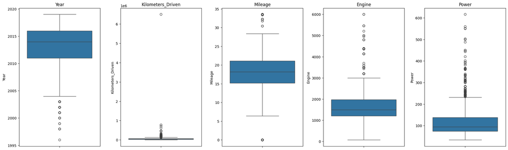

```python
import matplotlib.pyplot as plt
import seaborn as sns

numerical_cols = ['Year', 'Kilometers_Driven', 'Mileage', 'Engine', 'Power']

fig, axes = plt.subplots(1, 5, figsize=(20, 6), sharey=False)
for i, col in enumerate(numerical_cols):
    sns.boxplot(y=df[col], ax=axes[i])
    axes[i].set_title(col)

plt.tight_layout()
plt.show()
```

### **Observations:**

1.Year

- Range in your dataset: 1996 to 2019.
- Outliers might be older or newer than typical ranges, but in this dataset, 1996–2019 doesn’t look extreme. If you consider only recent used cars, you might decide to exclude cars older than a certain threshold.
2. Kilometers_Driven
- Range in your dataset: 171 to 6,500,000 km.
- Mean ~ 58,699, with a very large standard deviation.
- Extremely high values (e.g., above 500,000 km) may be unrealistic or very rare. This is the most prominent source of outliers, as evidenced by the boxplot.
3. Mileage
- Ranges from 0 to about 33.54.
- A mileage of 0 could be a data entry error or an actual outlier. Also check if extremely high mileages (e.g., > 30 kmpl) are valid for the types of cars in your dataset.
4. Engine
- Range: 72 cc to 5998 cc. The lower end (72 cc) might be an error or a special vehicle (e.g., two-wheeler data mistakenly included?). The upper end could be large SUVs or performance cars. Consider whether those extremes make sense for your analysis.
5. Power
- Range: 34.2 bhp to 616 bhp.
- 616 bhp might be a high-end sports car or a data error. Similarly, 34.2 bhp is on the low side but might be valid for a small car.

## **6. Univariate Analysis**

### **Analysis for Numerical Variables**

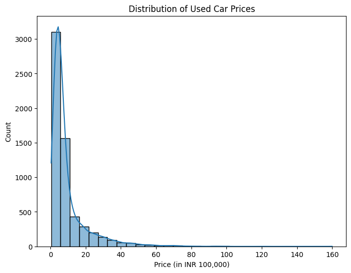

```
Skewness of Price: 3.3366548988495697
```

```python
# Histogram for Price
plt.figure(figsize=(8, 6))
sns.histplot(df['Price'], bins=30, kde=True)
plt.title("Distribution of Used Car Prices")
plt.xlabel("Price (in INR 100,000)")
plt.show()

# Check skewness
print("Skewness of Price:", df['Price'].skew())
```

### **Log Transformation**

#### The price distribution is highly skewed, so apply log transformation:

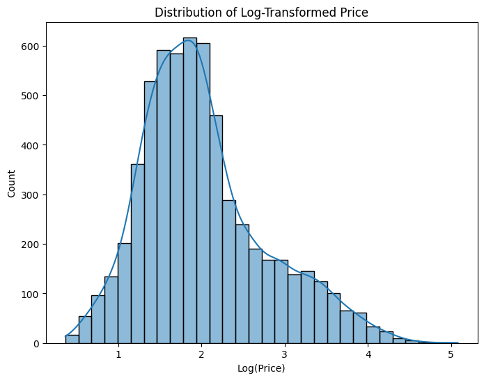

```python
# Apply log transformation
df.loc[:, 'price_log'] = np.log(df['Price'] + 1)


plt.figure(figsize=(8, 6))
sns.histplot(df['price_log'], bins=30, kde=True)
plt.title("Distribution of Log-Transformed Price")
plt.xlabel("Log(Price)")
plt.show()
```

### **Observations**

From the histogram of log(Price), it appears the distribution is indeed more symmetrical compared to the original Price distribution. Here are some key points:

1. Visual Inspection
- The histogram shows a more bell-shaped curve with a less pronounced right tail.
- This suggests the data has become less skewed.
2. Reduced Skewness
- Originally, the Price column had a skewness of around 3.34, indicating a highly right-skewed distribution.

## **7. Bivariate Analysis**

### **Scatter Plot for Log-Transformed Price vs. Key Variables**

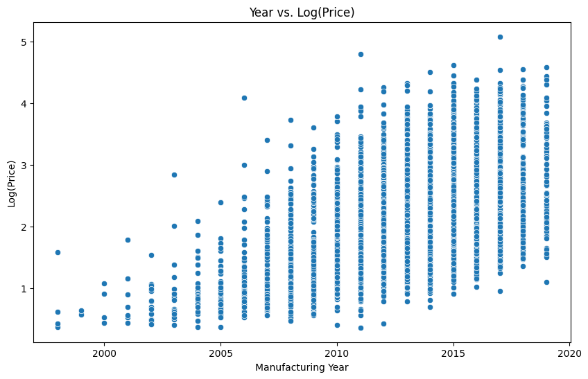

```python
# Scatter plot: Year vs. Log Price
plt.figure(figsize=(10, 6))
sns.scatterplot(x=df['Year'], y=df['price_log'])
plt.title("Year vs. Log(Price)")
plt.xlabel("Manufacturing Year")
plt.ylabel("Log(Price)")
plt.show()
```

### **Correlation Heatmap**

[figure not shown]

```python
import numpy as np
import seaborn as sns
import matplotlib.pyplot as plt

# Select only numeric columns
numeric_df = df.select_dtypes(include=[np.number])

# Create the heatmap
plt.figure(figsize=(12, 10))
sns.heatmap(numeric_df.corr(), annot=True, cmap='coolwarm')
plt.title("Correlation Heatmap (Numeric Columns Only)")
plt.show()
```

## **8. Feature Engineering and Missing Value Treatment**

### **Extracting Brand Name from 'Name'**

```python
# Extract the brand name (assumed as the first word in the Name)
df['Brand'] = df['Name'].apply(lambda x: x.split()[0])
print("Unique Brands:", df['Brand'].nunique())
```

```
Unique Brands: 33
```

### **Handling Missing Values**

```python
# Check for missing values after feature engineering
print("Missing Values After Feature Engineering:\n", df.isnull().sum())

# Example treatment: forward fill or imputation (modify as needed)
df.fillna(method='ffill', inplace=True)
```

[output not shown]

### **Observations**

#### **Missing Values After Feature Engineering**

- Overview of Missingness
- Mileage: 2 missing
- Engine: 46 missing
- Power: 175 missing
- Seats: 53 missing
- New_price: 6243 missing
- Price: 1234 missing
- price_log: 1234 missing (likely tied to missing values in “Price”)

## **9. Important Insights from EDA and Data Preprocessing**

### 1.Key Observations:

- Variables such as Year, Kilometers driven, and Mileage show significant variability and may strongly influence price.
- Log transformation of the price variable reduces skewness, making it more suitable for regression.
- Extracting the brand from the ‘Name’ column reduces dimensionality and could improve model performance.

### 2.Preprocessing Summary:

- Outliers have been identified and can be removed or treated.
- Missing values have been addressed.
- Categorical variables are ready for encoding.

## **10. Building Various Models**

### **10.1 Data Splitting and Preprocessing for Modeling**

Why Drop 'Name', 'Price', 'price_log', and 'Kilometers_driven'?

- Name: Contains too many unique values and is redundant after extracting the brand.
- Price and price_log: These are target variables and should not be part of the features to avoid data leakage.
- Kilometers_driven: Dropped here (if chosen) because it might be redundant or problematic based on EDA insights; however, this decision should be revisited based on further analysis.

```python
# Optional: Check the column names to verify spelling and case
print("Columns in the dataset:", df.columns.tolist())


# Forward fill missing values (note: if your data isn't sequential, consider using other imputation methods)
df.fillna(method='ffill', inplace=True)

# Extract 'Brand' from the 'Name' column (assuming the brand is the first word)
df['Brand'] = df['Name'].str.split().str[0]

# Create log-transformed price (avoid log(0) by adding 1)
df.loc[:, 'price_log'] = np.log(df['Price'] + 1)

# Create a log-transformed version of Kilometers_Driven if needed
df.loc[:, 'Kilometers_Driven_log'] = np.log1p(df['Kilometers_Driven'])

print("Missing values after processing:")
print(df.isnull().sum())

# Define columns to drop (make sure to use the exact column names)
features_to_drop = ['Name', 'Price', 'price_log', 'Kilometers_Driven']
X = df.drop(features_to_drop, axis=1)
y = df['price_log']  # using the log-transformed price as the target

# Display shapes to confirm the split
print("Shape of features (X):", X.shape)
print("Shape of target (y):", y.shape)

# Optional: Display first few rows of the features
print(X.head())
```

```
Columns in the dataset: ['S.No.', 'Name', 'Location', 'Year', 'Kilometers_Driven', 'Fuel_Type', 'Transmission', 'Owner_Type', 'Mileage', 'Engine', 'Power', 'Seats', 'New_price', 'Price', 'Kilometers_Driven_log', 'price_log', 'Brand']
Missing values after processing:
S.No.                    0
Name                     0
Location                 0
Year                     0
Kilometers_Driven        0
Fuel_Type                0
Transmission             0
Owner_Type               0
Mileage                  0
Engine                   0
Power                    0
Seats                    0
New_price                2
Price                    0
Kilometers_Driven_log    0
price_log                0
Brand                    0
dtype: int64
Shape of features (X): (7249, 13)
Shape of target (y): (7249,)
   S.No.    Location  Year Fuel_Type Transmission Owner_Type  Mileage  Engine  \
0      0      Mumbai  2010       CNG       Manual      First    26.60   998.0
1      1        Pune  2015    Diesel       Manual      First    19.67  1582.0
2      2     Chennai  2011    Petrol       Manual      First    18.20  1199.0
3      3     Chennai  2012    Diesel       Manual      First    20.77  1248.0
4      4  Coimbatore  2013    Diesel    Automatic     Second    15.20  1968.0

    Power  Seats  New_price  Kilometers_Driven_log    Brand
0   58.16    5.0        NaN              11.184435   Maruti
1  126.20    5.0        NaN              10.621352  Hyundai
2   88.70    5.0       8.61              10.736418    Honda
3   88.76    7.0       8.61              11.373675   Maruti
4  140.80    5.0       8.61              10.613271     Audi
```

### **10.2 Model Building and Evaluation**

#### **Linear Regression**

```python
# Use forward fill then backward fill to cover all missing data
df.ffill(inplace=True)
df.bfill(inplace=True)


# Extract 'Brand' from the 'Name' column (assuming brand is the first word)
df['Brand'] = df['Name'].str.split().str[0]

# Create log-transformed price (add 1 to avoid log(0))
df['price_log'] = np.log(df['Price'] + 1)

# Create log-transformed Kilometers_Driven
df['Kilometers_Driven_log'] = np.log1p(df['Kilometers_Driven'])


# Define columns to drop (using the correct column names)
features_to_drop = ['Name', 'Price', 'price_log', 'Kilometers_Driven']
X = df.drop(features_to_drop, axis=1)
y = df['price_log']  # using log-transformed price as the target

# Convert categorical variables to dummy/indicator variables
X = pd.get_dummies(X, drop_first=True)

# Verify that no missing values remain in X
print("Total missing values in X:", X.isnull().sum().sum())


X_train, X_test, y_train, y_test = train_test_split(X, y, test_size=0.2, random_state=42)
print("Training set shape:", X_train.shape)
print("Testing set shape:", X_test.shape)


lr_model = LinearRegression()
lr_model.fit(X_train, y_train)


y_pred_lr = lr_model.predict(X_test)
mse_lr = mean_squared_error(y_test, y_pred_lr)
print("Mean Squared Error for Linear Regression:", mse_lr)
```

```
Total missing values in X: 0
Training set shape: (5799, 58)
Testing set shape: (1450, 58)
Mean Squared Error for Linear Regression: 0.15099831926590288
```

### **Decision Tree Regression and Hyperparameter Tuning**

```python
# Decision Tree Regression
dt_model = DecisionTreeRegressor(random_state=42)
dt_model.fit(X_train, y_train)
y_pred_dt = dt_model.predict(X_test)
mse_dt = mean_squared_error(y_test, y_pred_dt)
print("Decision Tree MSE:", mse_dt)

# Hyperparameter Tuning for Decision Tree using GridSearchCV
param_grid_dt = {
    'max_depth': [5, 10, 15, 20],
    'min_samples_split': [2, 5, 10]
}
grid_dt = GridSearchCV(DecisionTreeRegressor(random_state=42),
                       param_grid_dt, cv=5, scoring='neg_mean_squared_error')
grid_dt.fit(X_train, y_train)
print("Best Decision Tree Parameters:", grid_dt.best_params_)
```

```
Decision Tree MSE: 0.06908138533666729
Best Decision Tree Parameters: {'max_depth': 15, 'min_samples_split': 10}
```

### **Random Forest Regression and Hyperparameter Tuning**

```python
# Random Forest Regression
rf_model = RandomForestRegressor(random_state=42)
rf_model.fit(X_train, y_train)
y_pred_rf = rf_model.predict(X_test)
mse_rf = mean_squared_error(y_test, y_pred_rf)
print("Random Forest MSE:", mse_rf)

# Hyperparameter Tuning for Random Forest using GridSearchCV
param_grid_rf = {
    'n_estimators': [50, 100, 150],
    'max_depth': [5, 10, 15, 20]
}
grid_rf = GridSearchCV(RandomForestRegressor(random_state=42),
                       param_grid_rf, cv=5, scoring='neg_mean_squared_error')
grid_rf.fit(X_train, y_train)
print("Best Random Forest Parameters:", grid_rf.best_params_)
```

```
Random Forest MSE: 0.035963888669111425
Best Random Forest Parameters: {'max_depth': 20, 'n_estimators': 150}
```

### **10.3 Feature Importance Analysis**

```
                      Feature    Importance
4                       Power  4.695890e-01
0                       S.No.  2.349799e-01
1                        Year  1.675820e-01
3                      Engine  3.649446e-02
7       Kilometers_Driven_log  1.375592e-02
22        Transmission_Manual  1.241233e-02
2                     Mileage  1.094143e-02
6                   New_price  8.171220e-03
45        Brand_Mercedes-Benz  4.447351e-03
46                 Brand_Mini  2.897694e-03
42                 Brand_Land  2.827365e-03
43             Brand_Mahindra  2.826836e-03
15           Location_Kolkata  2.785853e-03
5                       Seats  2.750104e-03
```

[output cut: 44 more lines]

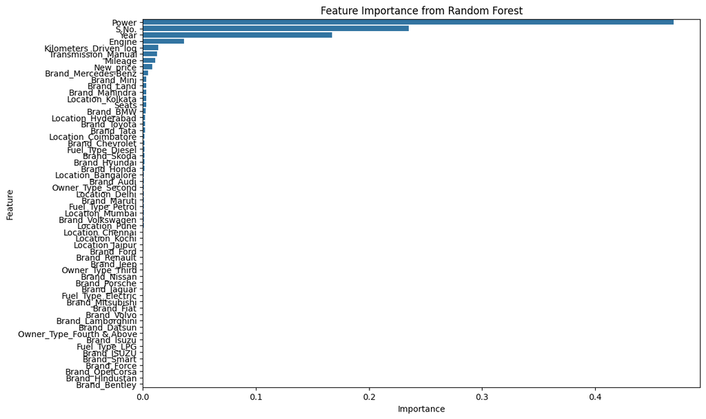

```python
# Feature Importance from Random Forest
importances = rf_model.feature_importances_
feature_names = X.columns
feature_importance_df = pd.DataFrame({'Feature': feature_names, 'Importance': importances})
feature_importance_df = feature_importance_df.sort_values(by='Importance', ascending=False)
print(feature_importance_df)

# Plotting feature importances
plt.figure(figsize=(12,8))
sns.barplot(x='Importance', y='Feature', data=feature_importance_df)
plt.title("Feature Importance from Random Forest")
plt.show()
```

## **11. Conclusions and Recommendations**

### **Comparison of Techniques**

- **Performance Metrics:**
- We evaluated models using Mean Squared Error (MSE).
- Compare the MSEs from Linear Regression, Decision Tree, and Random Forest.
- **Observations:**
- For instance, if the Random Forest model shows the lowest MSE, it may be the most suitable.
- There is scope for further improvement by refining feature engineering and tuning hyperparameters.

### **Poposal for the Final Solution Design**

- Recommended Model:
- Based on the evaluation, we propose adopting the Random Forest model (assuming it provides the best performance and interpretability).
- Justification:
- It offers robust performance against outliers and non-linear relationships.
- The feature importance analysis helps in understanding which factors most affect used car prices.
- Deployment Consideration:
- The chosen model should be further validated on unseen data and periodically re-trained to adapt to market changes.